# Data acquaintance for Mediterranean dataset (MEData)

Shira Salingré

# Introduction

Medata is a dataset of underwater fish census surveys conducted along the Mediterranean sea. The dataset includes environmental variables, as well as conservation information regarding MPAs.

This is a collaboration of [Belmaker Lab](https://belmaker.weebly.com/) (Tel Aviv University, Israel), [Ernesto Azzuro](https://www.researchgate.net/profile/Ernesto_Azzurro) (ISPRA, Italy), [Joachim Claudet](http://www.joachimclaudet.com/) (CNRS, France) and [Enric Sala](https://www.researchgate.net/profile/Enric_Sala).

```r
medata <- read_rds("data/medata.Rds")
```

# Variables

[output not shown]

# Overview

```r
summary(medata)
```

```
##      data.origin       country         season           lon
##  azz_asi   : 3875   Italy  :13380   autumn:18171   Min.   : 1.159
##  azz_malt  : 4179   Israel :10331   spring: 5318   1st Qu.: 8.218
##  Belmaker  :25686   Greece : 6424   summer:19362   Median :15.443
##  Sala - PEW: 9111   France : 3617                  Mean   :18.731
##                     Croatia: 3508                  3rd Qu.:29.052
##                     Spain  : 2959                  Max.   :35.076
##                     (Other): 2632
##       lat                 site           trans      protection
##  Min.   :32.42   asinara_add: 3033   Min.   :   1   Mode :logical
##  1st Qu.:35.01   gdor       : 2941   1st Qu.: 335   FALSE:18655
##  Median :37.98   achziv     : 2902   Median :1474   TRUE :23874
##  Mean   :37.75   shikmona   : 2378   Mean   :1285   NA's :322
##  3rd Qu.:41.05   habonim    : 2110   3rd Qu.:2026
##  Max.   :44.94   malta      : 1582   Max.   :2392
##                  (Other)    :27905
##  enforcement   total.mpa.ha        size.notake       yr.creation
##  0   :18655   Min.   :    15.95   Min.   :   18.0   2002   : 8879
##  1   : 6723   1st Qu.:   167.70   1st Qu.:  167.7   1962   : 3617
##  2   : 9135   Median :  1000.00   Median :  600.0   1960   : 3508
##  3   : 8016   Mean   :  5782.98   Mean   : 3183.7   1986   : 3126
##  NA's:  322   3rd Qu.:  2375.00   3rd Qu.: 2651.0   2004   : 2941
##               Max.   :207000.00   Max.   :15000.0   (Other): 9413
##               NA's   :16001       NA's   :19618     NA's   :11367
##  age.reserve.yr      depth            tmean           trange
##  1      : 3875   Min.   : 1.800   Min.   :16.80   Min.   : 9.172
##  55     : 3617   1st Qu.: 5.200   1st Qu.:18.66   1st Qu.:10.990
##  57     : 3508   Median :10.000   Median :20.01   Median :11.696
##  32     : 3126   Mean   : 9.216   Mean   :20.01   Mean   :11.774
##  9      : 3064   3rd Qu.:10.000   3rd Qu.:21.65   3rd Qu.:12.160
##  (Other):14294   Max.   :29.000   Max.   :22.97   Max.   :15.843
##  NA's   :11367   NA's   :16376
##     sal_mean        pp_mean             pp_range
##  Min.   :33.99   Min.   :0.0002631   Min.   :0.0007501
##  1st Qu.:37.67   1st Qu.:0.0005210   1st Qu.:0.0017613
##  Median :37.83   Median :0.0006510   Median :0.0026778
##  Mean   :38.05   Mean   :0.0029182   Mean   :0.0070171
##  3rd Qu.:38.77   3rd Qu.:0.0061386   3rd Qu.:0.0115235
##  Max.   :39.24   Max.   :0.0098922   Max.   :0.0268522
##  NA's   :1366
```

[output cut: 9 more lines]

```
##  Min.   :2.028   Labridae     :18903   Mode :logical   Min.   :2.000
##  1st Qu.:2.962   Sparidae     : 9873   FALSE:40031     1st Qu.:3.240
##  Median :3.073   Serranidae   : 4057   TRUE :2807      Median :3.340
##  Mean   :3.016   Pomacentridae: 2753   NA's :13        Mean   :3.273
##  3rd Qu.:3.111   Siganidae    : 2183                   3rd Qu.:3.500
##  Max.   :3.393   Scaridae     : 1149                   Max.   :4.500
##  NA's   :2176    (Other)      : 3933                   NA's   :627
##   FoodSeTroph
##  Min.   :0.0000
##  1st Qu.:0.4100
##  Median :0.4300
##  Mean   :0.4243
##  3rd Qu.:0.4700
##  Max.   :0.8500
##  NA's   :627
```

```r
skimr::skim(medata)
```

Data summary

| Name | medata |
| --- | --- |
| Number of rows | 42851 |
| Number of columns | 28 |
| _______________________ |  |
| Column type frequency: |  |
| factor | 9 |
| logical | 2 |
| numeric | 17 |
| ________________________ |  |
| Group variables | None |

**Variable type: factor**

| skim_variable | n_missing | complete_rate | ordered | n_unique | top_counts |
| --- | --- | --- | --- | --- | --- |
| data.origin | 0 | 1.00 | FALSE | 4 | Bel: 25686, Sal: 9111, azz: 4179, azz: 3875 |
| country | 0 | 1.00 | FALSE | 8 | Ita: 13380, Isr: 10331, Gre: 6424, Fra: 3617 |
| season | 0 | 1.00 | FALSE | 3 | sum: 19362, aut: 18171, spr: 5318 |
| site | 0 | 1.00 | FALSE | 224 | asi: 3033, gdo: 2941, ach: 2902, shi: 2378 |
| enforcement | 322 | 0.99 | FALSE | 4 | 0: 18655, 2: 9135, 3: 8016, 1: 6723 |
| yr.creation | 11367 | 0.73 | FALSE | 14 | 200: 8879, 196: 3617, 196: 3508, 198: 3126 |
| age.reserve.yr | 11367 | 0.73 | FALSE | 17 | 1: 3875, 55: 3617, 57: 3508, 32: 3126 |
| species | 0 | 1.00 | FALSE | 123 | Tha: 6341, Cor: 6178, Dip: 3063, Dip: 2923 |
| family | 0 | 1.00 | FALSE | 39 | Lab: 18903, Spa: 9873, Ser: 4057, Pom: 2753 |

**Variable type: logical**

| skim_variable | n_missing | complete_rate | mean | count |
| --- | --- | --- | --- | --- |
| protection | 322 | 0.99 | 0.56 | TRU: 23874, FAL: 18655 |
| exotic | 13 | 1.00 | 0.07 | FAL: 40031, TRU: 2807 |

**Variable type: numeric**

| skim_variable | n_missing | complete_rate | mean | sd | p0 | p25 | p50 | p75 | p100 | hist |
| --- | --- | --- | --- | --- | --- | --- | --- | --- | --- | --- |
| lon | 0 | 1.00 | 18.73 | 11.43 | 1.16 | 8.22 | 15.44 | 29.05 | 35.08 | ▅▇▂▅▆ |
| lat | 0 | 1.00 | 37.75 | 3.90 | 32.42 | 35.01 | 37.98 | 41.06 | 44.94 | ▇▇▅▆▆ |
| trans | 0 | 1.00 | 1285.41 | 845.64 | 1.00 | 335.00 | 1474.00 | 2026.00 | 2392.00 | ▇▁▅▆▇ |
| total.mpa.ha | 16001 | 0.63 | 5782.98 | 21635.07 | 15.95 | 167.70 | 1000.00 | 2375.00 | 207000.00 | ▇▁▁▁▁ |
| size.notake | 19618 | 0.54 | 3183.65 | 5352.66 | 18.00 | 167.70 | 600.00 | 2651.00 | 15000.00 | ▇▁▁▁▂ |
| depth | 16376 | 0.62 | 9.22 | 5.12 | 1.80 | 5.20 | 10.00 | 10.00 | 29.00 | ▆▇▂▁▁ |
| tmean | 0 | 1.00 | 20.01 | 1.98 | 16.80 | 18.66 | 20.01 | 21.65 | 22.97 | ▅▇▇▂▇ |
| trange | 0 | 1.00 | 11.77 | 1.08 | 9.17 | 10.99 | 11.70 | 12.16 | 15.84 | ▁▇▃▁▁ |
| sal_mean | 1366 | 0.97 | 38.05 | 0.87 | 33.99 | 37.67 | 37.83 | 38.77 | 39.24 | ▁▁▁▇▇ |
| pp_mean | 0 | 1.00 | 0.00 | 0.00 | 0.00 | 0.00 | 0.00 | 0.01 | 0.01 | ▇▂▁▃▁ |
| pp_range | 0 | 1.00 | 0.01 | 0.01 | 0.00 | 0.00 | 0.00 | 0.01 | 0.03 | ▇▂▃▁▁ |
| sp.n | 0 | 1.00 | 16.82 | 155.39 | 0.00 | 1.00 | 1.00 | 4.00 | 10000.00 | ▇▁▁▁▁ |
| sp.length | 842 | 0.98 | 11.61 | 7.53 | 0.00 | 8.00 | 10.00 | 15.00 | 150.00 | ▇▁▁▁▁ |
| a | 2176 | 0.95 | 0.01 | 0.01 | 0.00 | 0.01 | 0.01 | 0.02 | 0.11 | ▇▁▁▁▁ |
| b | 2176 | 0.95 | 3.02 | 0.14 | 2.03 | 2.96 | 3.07 | 3.11 | 3.39 | ▁▁▁▇▁ |
| FoodTroph | 627 | 0.99 | 3.27 | 0.39 | 2.00 | 3.24 | 3.34 | 3.50 | 4.50 | ▁▁▇▁▁ |
| FoodSeTroph | 627 | 0.99 | 0.42 | 0.13 | 0.00 | 0.41 | 0.43 | 0.47 | 0.85 | ▁▁▇▁▁ |

## Countries

Data was collected from 8 countries:

```r
medata %>% distinct(country) %>% arrange(.$country) %>% print(n = Inf)
```

```
## # A tibble: 8 x 1
##   country
##   <fct>
## 1 Croatia
## 2 France
## 3 Greece
## 4 Israel
## 5 Italy
## 6 Malta
## 7 Spain
## 8 Turkey
```

## Species

Dataset withholds 118 species

```r
medata %>% distinct(species) %>% arrange(.$species) %>% count()
```

```
## # A tibble: 1 x 1
##       n
##   <int>
## 1   123
```

```r
# proper species
medata %>% distinct(species) %>% arrange(.$species) %>%
  filter(!c(grepl("dae", species) | grepl(".spp", species))) %>%
  print(n = Inf)
```

```
## # A tibble: 118 x 1
##     species
##     <fct>
##   1 Abudefduf.saxatilis
##   2 Anthias.anthias
##   3 Apogon.imberbis
##   4 Atherina.boyeri
##   5 Balistes.capriscus
##   6 Belone.belone
##   7 Boops.boops
##   8 Caranx.crysos
##   9 Cheilodipterus.novemstriatus
##  10 Chelon.labrosus
##  11 Chromis.chromis
##  12 Conger.conger
```

[output cut: 106 more lines]

**NOTE**: There are 123 taxa in the dataset but some are not species but genus (Atherina.spp, Symphodus.spp) or family (Labridae, Clupeidae, Belonidae).

# Methods

## Data collection

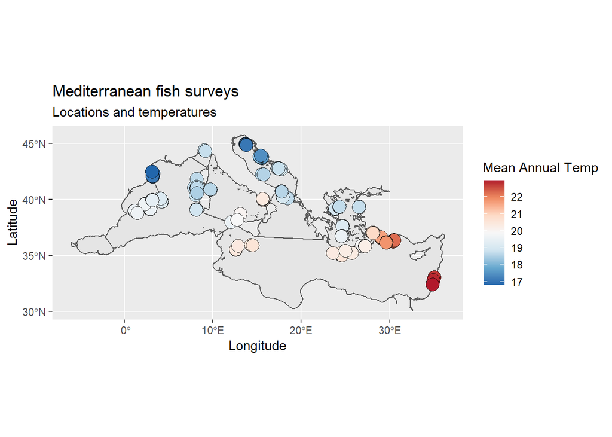

Figure 1. Survey sites and temperatures (in degrees celsius).

## Data acquired from other resources

**Environmental data** (temperature, salinity and primary production) were acquired from [Bio-ORACLE](http://http://www.bio-oracle.org) using `sdmpredictors` package.

**Layers**:

- tmean = “BO_sstmean”
- trange = “BO_sstrange”
- sal_mean = “BO2_salinitymean_ss”
- pp_mean = “BO2_ppmean_ss”
- pp_range = “BO2_pprange_ss”

(See “~/R/bio-oracle extraction code.R” for full extraction code).

## Data wrangling notes

- Linosa and kornati did not have specific coordinates, therefore, an approximate location (lat-lon) was attached to it. If your analysis requires fine-detail for the location, you might want to omit these locations.
- Data from source `asinara_add` site are presence-absence only.

### Transformations

Many analyses require species matrix where each row is a site and each column is a species.

Here’s the code to create such matrix with this dataset:

```r
# Create a tibble of metadata
med_meta <- medata %>%
  distinct(country, site, lon, lat, season, protection, enforcement, total.mpa.ha, size.notake,
           yr.creation, age.reserve.yr, tmean, trange, sal_mean, pp_mean, pp_range)

# Create a species matrix with summation of each species in each site (abundance)
med_mat <- medata %>%
  group_by(site, lon, lat, species) %>% # Sites and species (with coordinate-locations) only
  summarise(n = sum(sp.n)) %>%
  spread(species, n, fill = 0)
# Put the 2 data sets together (species and metadata)
full_med_mat <- left_join(med_meta, med_mat, by = c("site", "lon", "lat"))

# Convert the abundance data to pseudo presence-absence
pres_abs_mat <- full_med_mat
pres_abs_mat[17:ncol(pres_abs_mat)] <- ifelse(pres_abs_mat[17:ncol(pres_abs_mat)] > 0, 1, 0) # col 17 is the 1st species
```

# View the data

## Species richness

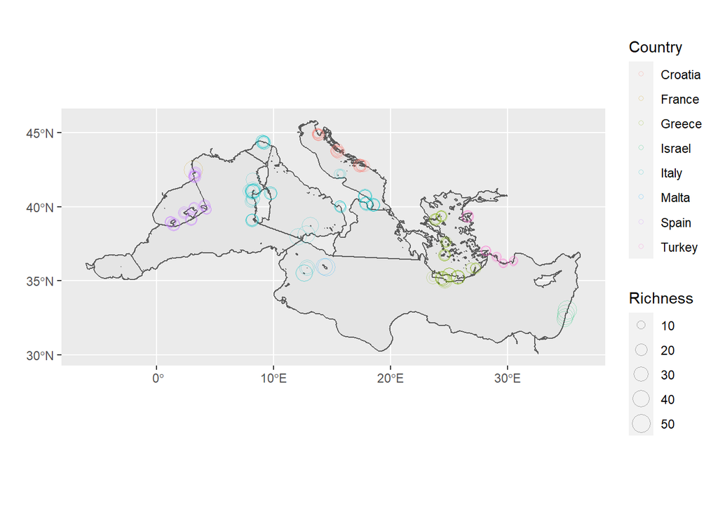

```r
medata %>%
  group_by(country, lon, lat) %>%
  distinct(species) %>% summarise(richness = n()) %>%
  ggplot() +
  geom_sf(data = med_map$geometry) +
  geom_point(aes(x = lon, y = lat, size = richness, col = country), pch = 21, alpha = 0.3) +
  labs(x = "", y = "", size = "Richness", col = "Country")
```

## Lessepsian migrants

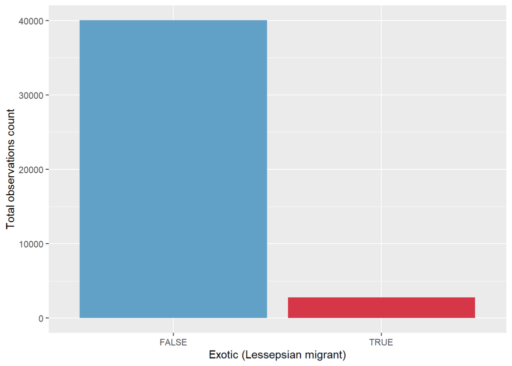

```r
medata %>% filter(!is.na(exotic)) %>%
  ggplot() + aes(x = exotic) + geom_bar(fill = c("#62a1c7", "#d53748")) +
  labs(x = "Exotic (Lessepsian migrant)", y = "Total observations count")
```

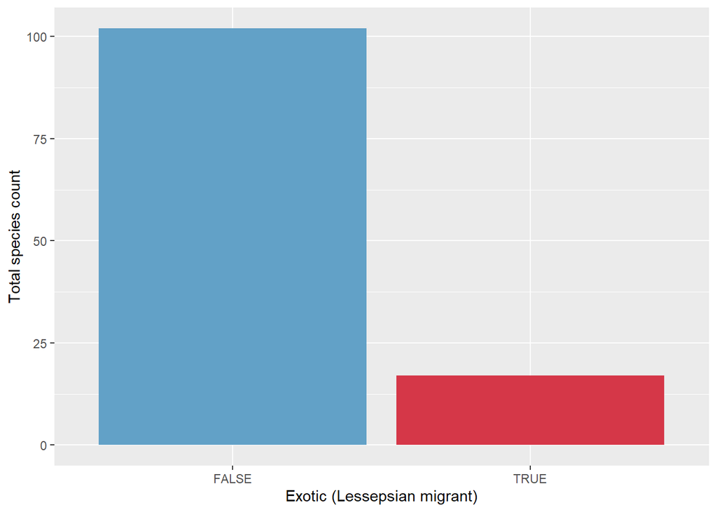

```r
medata %>% filter(!is.na(exotic)) %>% distinct(species, exotic) %>%
  ggplot() + aes(x = exotic) + geom_bar(fill = c("#62a1c7", "#d53748")) +
  labs(x = "Exotic (Lessepsian migrant)", y = "Total species count")
```

# References

Froese, R. and D. Pauly. Editors. 2021.FishBase. World Wide Web electronic publication. www.fishbase.org, (06/2021)

Boettiger C, Temple Lang D, Wainwright P (2012). “rfishbase: exploring, manipulating and visualizing FishBase data from R.” Journal of Fish Biology

Assis J, Tyberghein L, Bosch S, Heroen V, SerrÃ£o E, De Clerck O, Tittensor D (2018). Bio-ORACLE v2.0: Extending marine data layers for bioclimatic modelling." *Global Ecology and Biogeography*, *27*(3),277-284. doi: 10.1111/geb.12693 (https://doi.org/10.1111/geb.12693).

Tyberghein L, Heroen V, Pauly K, Troupin C, Mineur F, De Clerck O (2012). Bio-ORACLE: a global environmental dataset for marine speciesdistribution modelling." *Global Ecology and Biogeography*, *21*(2),272-281. doi: 10.1111/j.1466-8238.2011.00656.x (https://doi.org/10.1111/j.1466-8238.2011.00656.x).